# Exploration of 2016 Presidential Campaign by Steven Lin

Below is table to sort by average countribution per contributor.

```
## # A tibble: 10 x 4
##           County Total_Contr      n contr_per_person
##            <chr>       <dbl>  <int>            <dbl>
##  1        Alpine     13669.5     45         303.7667
##  2     San Mateo   9112487.0  43428         209.8298
##  3 San Francisco  15857027.2  89951         176.2852
##  4          Inyo    115937.0    785         147.6905
##  5   Los Angeles  49353868.0 335482         147.1133
##  6   Santa Clara  12338977.4  84486         146.0476
##  7          <NA>    353259.5   2429         145.4341
##  8         Marin   4695365.2  32619         143.9457
##  9        Orange  11251631.6  84152         133.7061
## 10         Kings    110158.3    889         123.9126
```

Following I’d also like to visualize the contribution amount by County using bar chart. This gives similar information as above, but I can get a feel of the relative difference amount top 10. Los Angles exceed the other County by large margin.

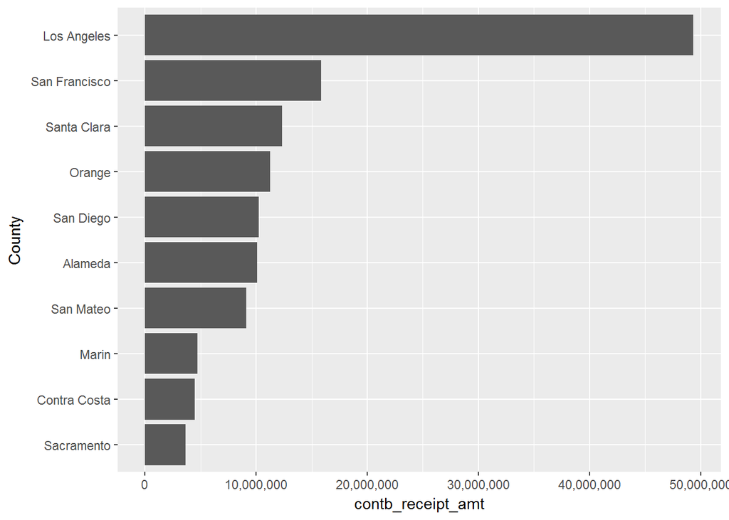

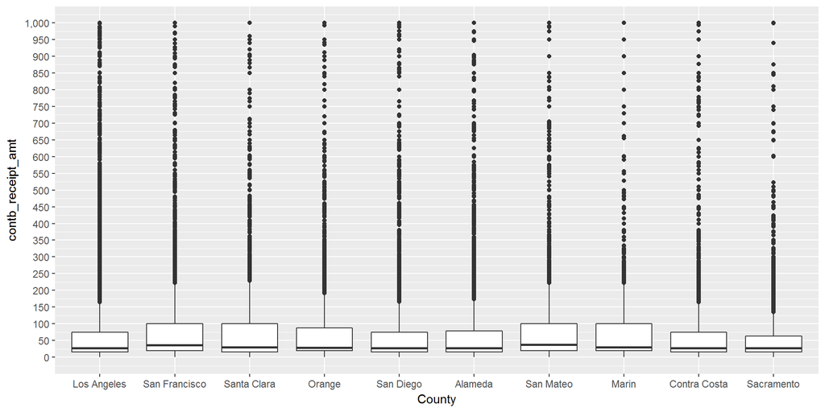

Next, I’d like to see the total contribution amount by occupation (different from above plot exploring the number of contribution rather than the total contribution amount.) I compare this ranking by contribution amount with the ranking by number of contribution to notice that “RETIRED”" is still the first place, but “ATTORNEY” jump to second place, signaling Attorney’s average contribution are much higher than the thrid place “NOT EMPLOYED”. And then “HOMEMAKER”" and “CEO” jump ahead replacing “TEACHER” and “ENGINEER”, signaling that HOMEMAKER and CEO contribute higher on average.

```
## # A tibble: 28,563 x 2
##        contbr_occupation  sum_amt
##                   <fctr>    <dbl>
##  1               RETIRED 25760178
##  2              ATTORNEY  8313986
##  3          NOT EMPLOYED  6493037
##  4 INFORMATION REQUESTED  5424681
##  5             HOMEMAKER  4995228
##  6                   CEO  3536462
##  7             PHYSICIAN  2680283
##  8            CONSULTANT  2518305
##  9             PRESIDENT  2480685
## 10                LAWYER  2183138
## # ... with 28,553 more rows
```

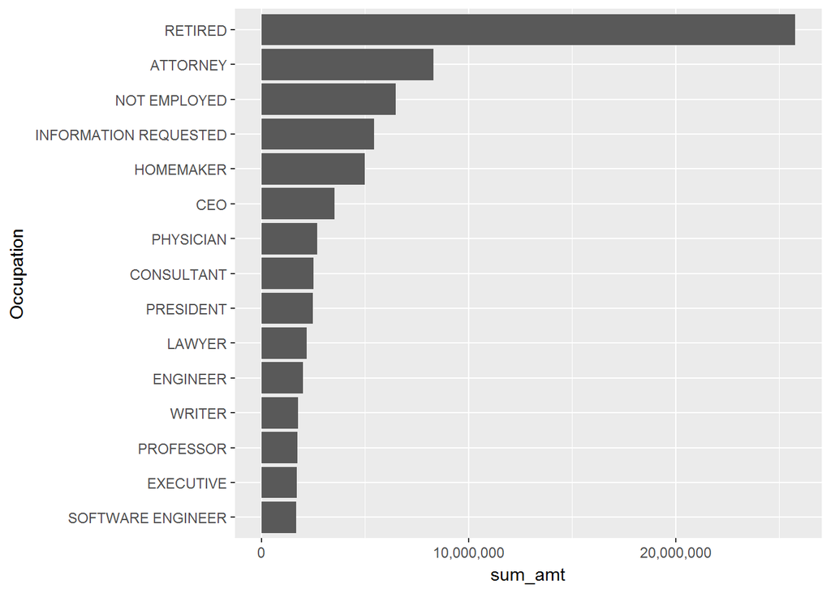

Next I’d like to see the contribution amonut by Employer, and to compare with one of the previous plot showing number of contribution by Employer. In contrast to the ranking in number of contribution, the ranking in contribution amount also have ‘SELF-EMPLOYED’, ‘RETIRED’ and ‘NOT EMPLOYED’ at the top. However, the “HOMEMAKER” is the first one coming after, even higher than GOOGLE and KAISER PERMANENTE which is interesting to see, and is a bit puzzling to me because I doubt HOMEMAKER can earn more than high tech engineer, but perhaps I underestimate HOMEMAKER’s degree of involvement and their income source. It is one potential question I can dig further.

```
## # A tibble: 65,457 x 2
##                           contbr_employer  sum_amt
##                                    <fctr>    <dbl>
##  1                          SELF-EMPLOYED 20602871
##  2                                    N/A 19042888
##  3                                RETIRED 13983832
##  4                  INFORMATION REQUESTED  5288152
##  5                           NOT EMPLOYED  4013299
##  6                                   NONE  3689913
##  7                          SELF EMPLOYED  3138496
##  8                                   SELF  2270388
##  9                              HOMEMAKER  1974499
## 10 INFORMATION REQUESTED PER BEST EFFORTS  1607341
## # ... with 65,447 more rows
```

Following is to visualize the contribution amount by Employer using bar plot, that is to visualize the comparison.

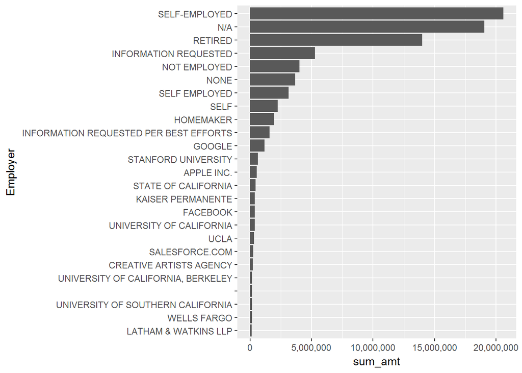

Excluding any N/A or None, Self-Employed is the highest contributor, and follow by Retired, Homemaker. The first company name appear is Google ! Then Stanford University, and Apple. This ranking differ a bit from the number of contributor count.

Next, I’d like to see how total contribution amount varies with times. My initial plot below is not successful as I expected because it shows too much fluctuation, so I will need to further adjust it.

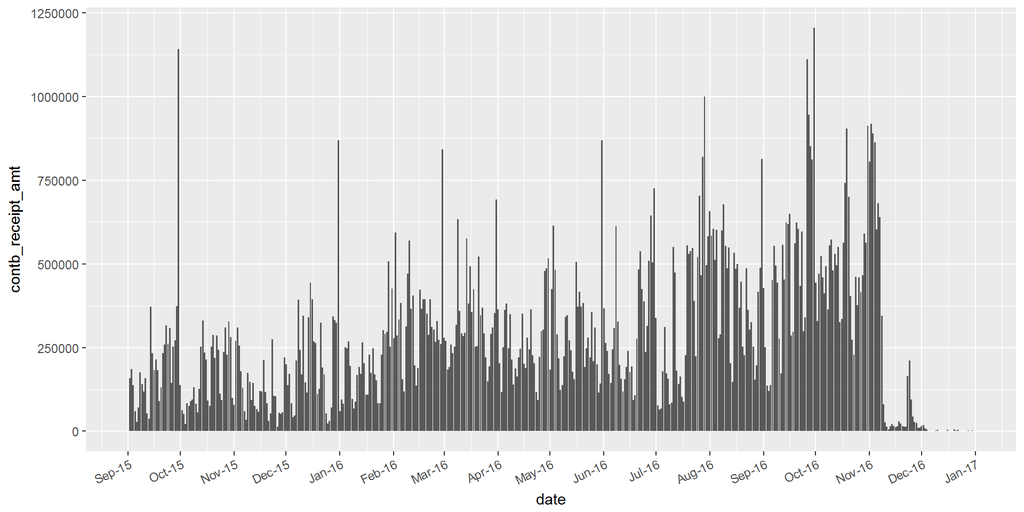

To improve on the visualization, I will create a dataframe utilizing library zoo with as.yearmon function. And I will do plotting based on this dataframe.

```
## # A tibble: 16 x 3
##             date     sum_amt      n
##    <S3: yearmon>       <dbl>  <int>
##  1      Oct 2016 15395999.15 157081
##  2      Sep 2016 15333139.19 117783
##  3      Aug 2016 13349203.80  94806
##  4      Jul 2016 10830494.75 105274
##  5      Mar 2016 10322590.94 137856
##  6      Feb 2016  9985479.81  97203
##  7      May 2016  9420341.83 100596
##  8      Jun 2016  9353511.90  87867
##  9      Apr 2016  8019722.41 125536
## 10      Dec 2015  6977826.59  35905
## 11      Nov 2016  6632596.66  77134
## 12      Sep 2015  6448841.73  18271
## 13      Jan 2016  6108022.96  47267
## 14      Oct 2015  5187916.73  26505
## 15      Nov 2015  3695284.47  23221
## 16      Dec 2016    82549.06    552
```

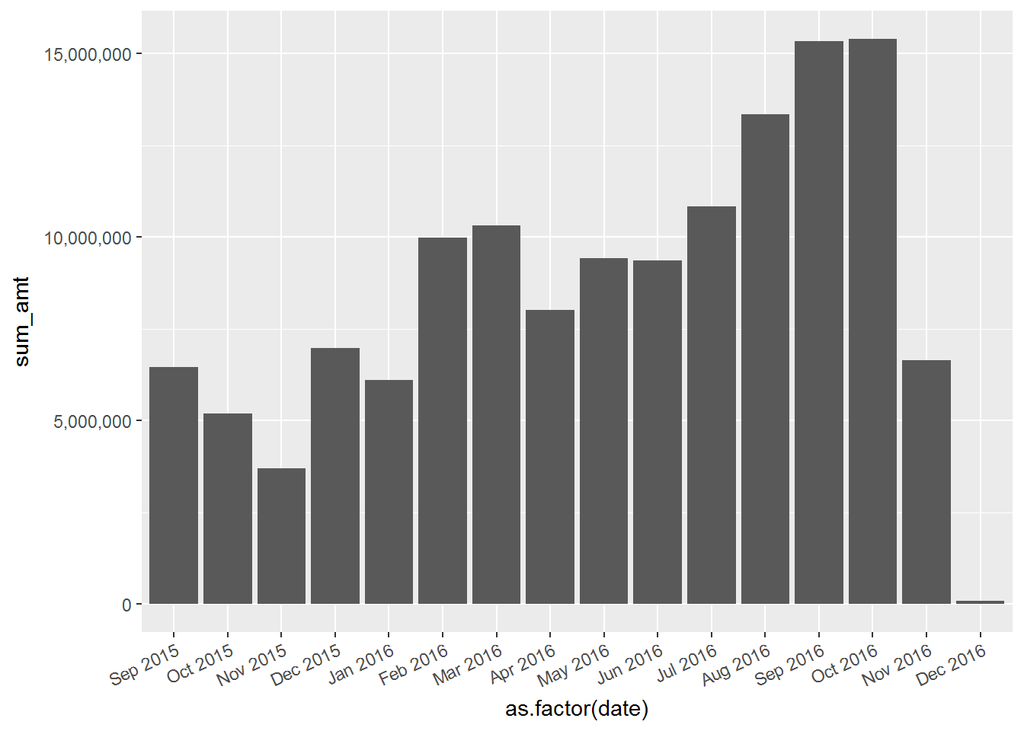

Next, I would like to use scatter plot to see the distribution of each contribution amount by date, and to see whether the each contribution amount may increase or decrease as it gets closer to election date.

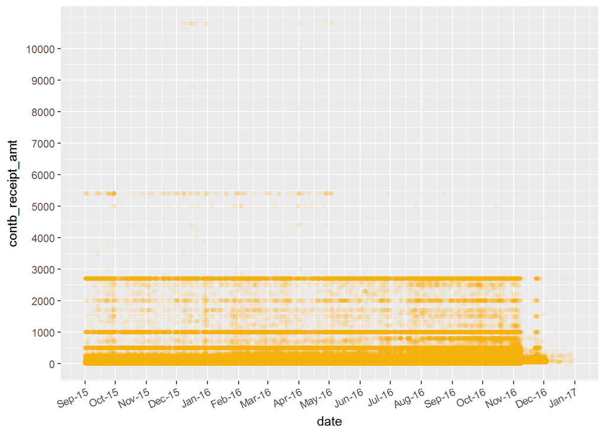

The plot looks rather flat with several popular contribution amount. The most popular contribution amount is still under $500 (and from one of the previous plot I know more than 75% percentile is under $88. However, it is also interesting to see that $1000, $2000 and $2750 seems also pretty popular amount, so I am suspecting there is a pre-determined options for contributor to select for their contribution. In $5500 range is also interesting showing larger contributor, may be interesting to see the cause.

However, the above is a little too crowded for me, so let me limit the contribution amount to be within 99% percentile, hope it may show me more detail.

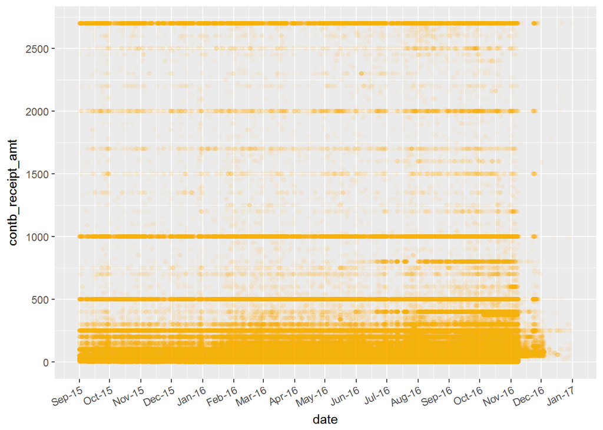

From above plot that limit the y-axis to $2750 range, it still looks pretty flat, meaning people have similar preference of contribution amount across time. However, at some amount range it seems to appear more as time closer to election date, for example, the $800 range, and $400 range.

Next, I’d like to see how is the contribution amount differ by candidate’s age. The 70 shows get the most or contribution. And I know the reason is because Hillary is at her 70. So this chart illustrate the candidates who get the most contribution are higher than 70 year-of-old.

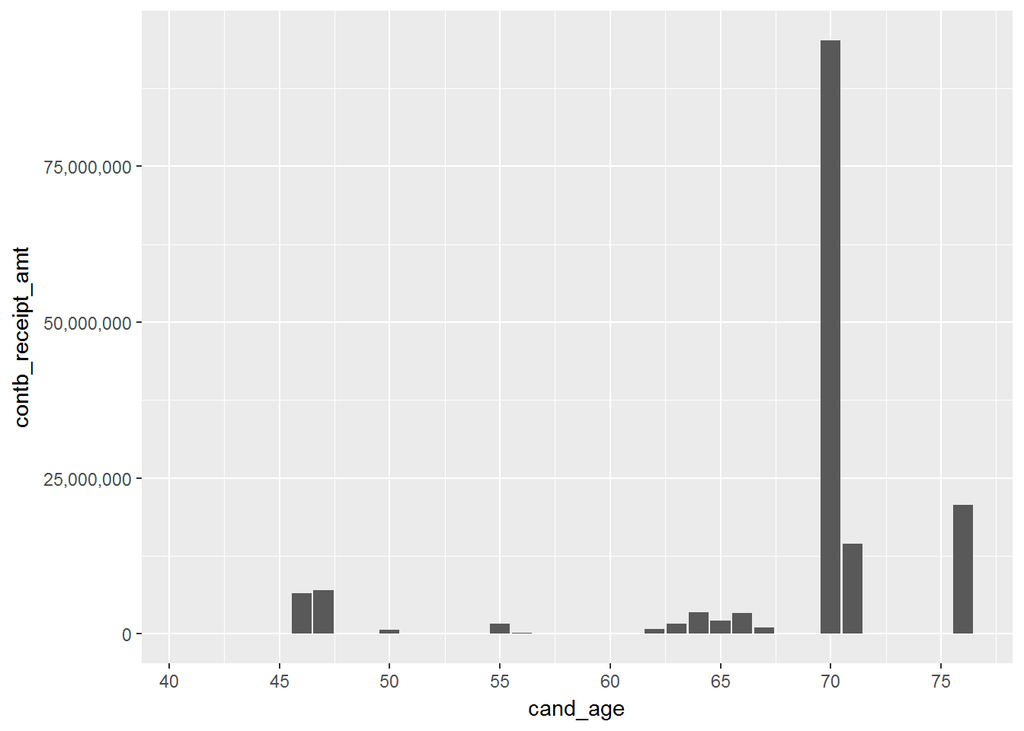

# Bivariate Analysis

### Talk about some of the relationships you observed in this part of the investigation. How did the feature(s) of interest vary with other features in the dataset?

I also confirm that the contributino amount by month are increasing as it gets closer to the election day. However, the average contribution amount doesn’t show significant difference as it gets close to election day.

### Did you observe any interesting relationships between the other features (not the main feature(s) of interest)?

I am trying to do correlation between each contributor’s contribution amount, date and candidates age, but there shows little correlation, meaning that each contributor’s contribution amount don’t get significant increase as it gets closer to election day. However, it is clear to me by another plot in univariate analysis, the number of contriution increaes as it gets closer to election day.

### What was the strongest relationship you found?

The strongest relationship I found perhaps it the steady increasing trend of total contribution amount by month increases as it gets close to election day.

# Multivariate Plots Section

Following I’d like to introduce more variable into the plot. The first is to use the total contribution amount by county, and further split by candidate’s gender.

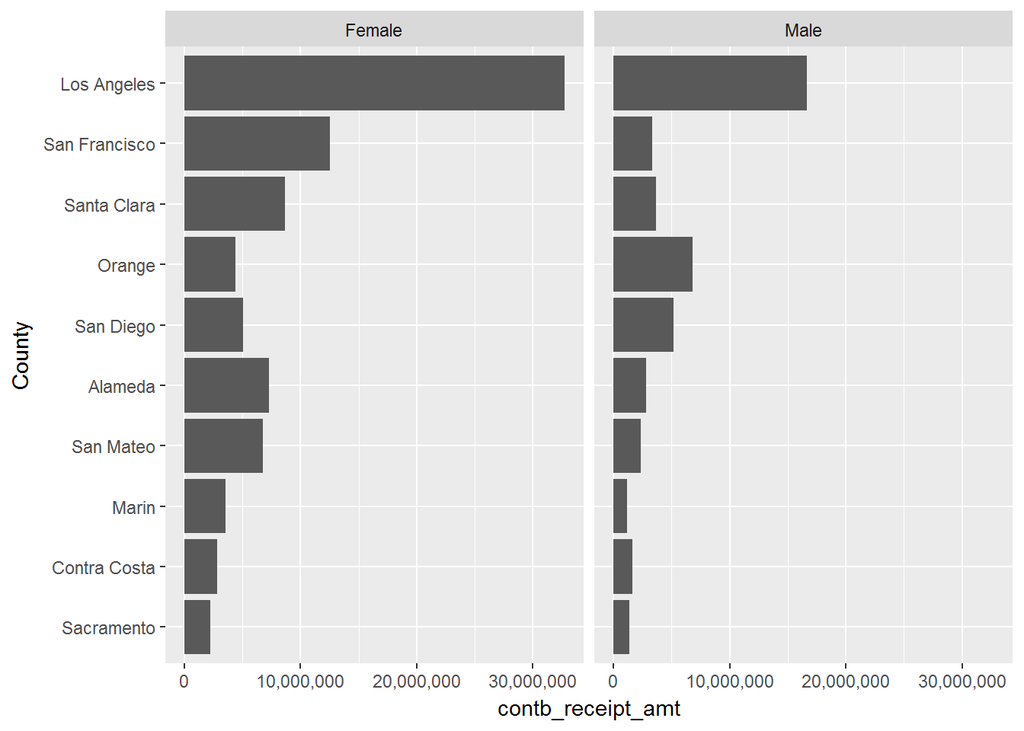

The above bar plot shows only 1 county, Orange, out of the top 10, shows to have more contribution amount to Male candidate than Female candidate. The rest of the county all have more contribution to female candidate than male, that must be to Hillary.

I am curious to see which male candidate in Orange county is doing so well that exceed Hillary, so plot followed is to see the contribution by candidate in Orange county only.

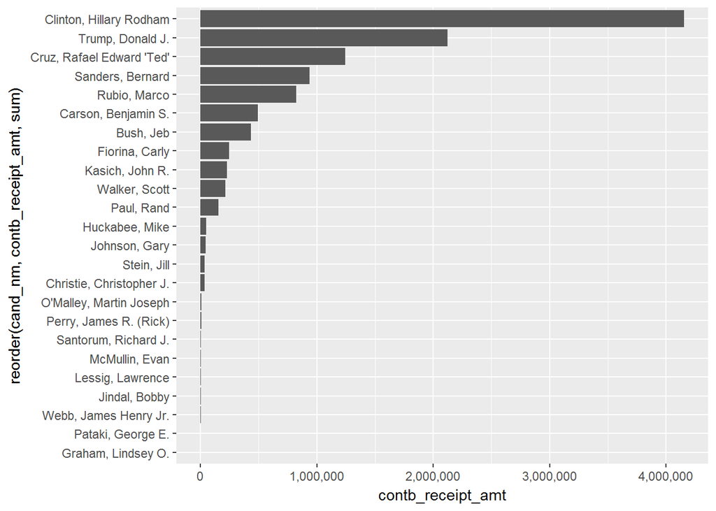

The plot above that narrow to see Orange County, shows that Donald Trump is getting large portion of contribution amount, just second to Hillary. It looks like that Donald Trump has many supporter in Orange county area, which I believe is one of the reason that only in Orange there are more contribution to Male candidate than Female candidate.

Next, I’d like to see the contribution amount by County, political party and candidate gender.

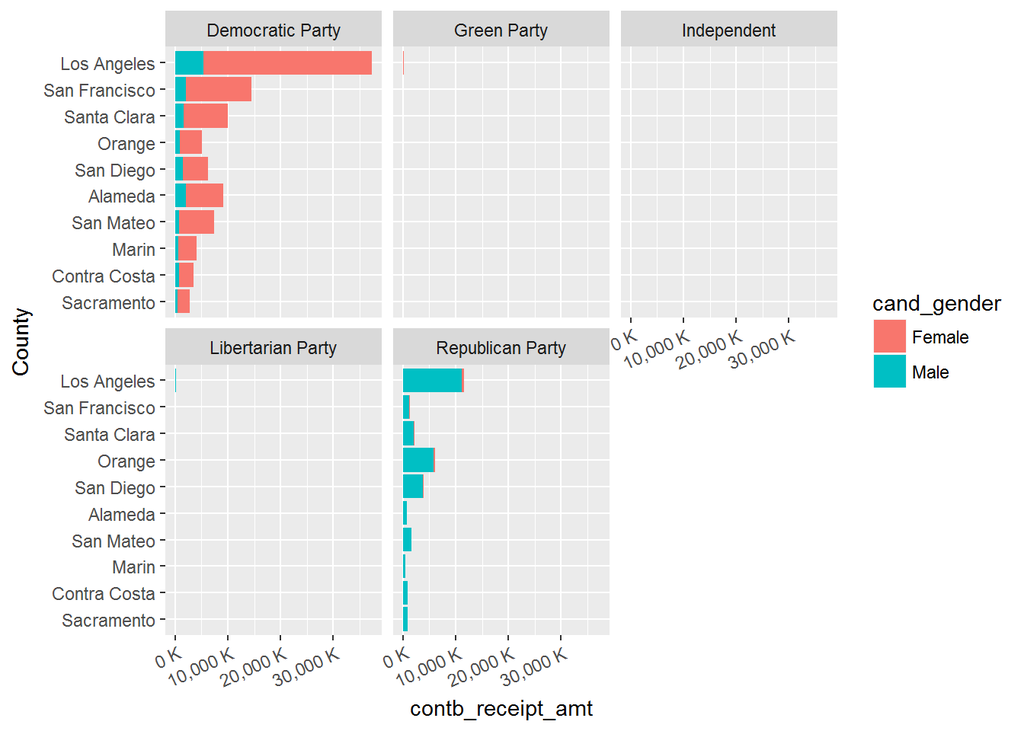

The plot above illustrate that Democratic party is the big winner in receiving contribution, but majority is to female candidate (ie. Hillary), while Republican is the next biggest winner but almost all contribution is to male candidate.

I would like to improve the plot slightly to separate male and female bar to both start from 0 to make easier comparison between male and female. The plot following to achieve it.

```
## # A tibble: 345 x 5
## # Groups:   County, cand_party [235]
##           County       cand_party cand_gender  sum_amt      n
##           <fctr>           <fctr>      <fctr>    <dbl>  <int>
##  1   Los Angeles Democratic Party      Female 32088628 198285
##  2 San Francisco Democratic Party      Female 12392225  56178
##  3   Los Angeles Republican Party        Male 11182307  36454
##  4   Santa Clara Democratic Party      Female  8511481  48796
##  5       Alameda Democratic Party      Female  7134724  54135
##  6     San Mateo Democratic Party      Female  6630340  27238
##  7        Orange Republican Party        Male  5815780  25036
##  8   Los Angeles Democratic Party        Male  5315834  98886
##  9     San Diego Democratic Party      Female  4852098  49510
## 10        Orange Democratic Party      Female  4152860  38545
## # ... with 335 more rows
```

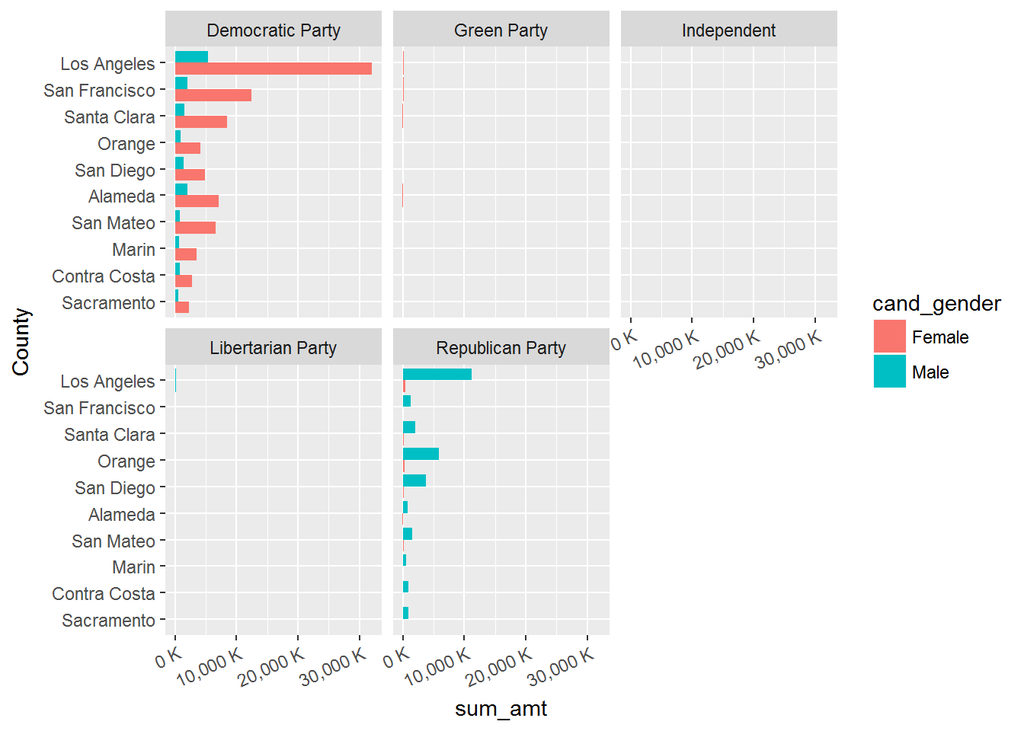

The plot above successfully list male and female bar separately, to make it easier to compare. And it helps me to easily identify that the reason the “Orange county” has more contribution to male candidate than female candidate is because of strong contribution to Republican Party (ie. Donald Trump). Orange county is the second highest county for Republican Party, second to Los Angeles county.

Review what are top 10 county with highest contribution amount.

```
##  [1] "Los Angeles"   "San Francisco" "Santa Clara"   "Orange"
##  [5] "San Diego"     "Alameda"       "San Mateo"     "Marin"
##  [9] "Contra Costa"  "Sacramento"
```

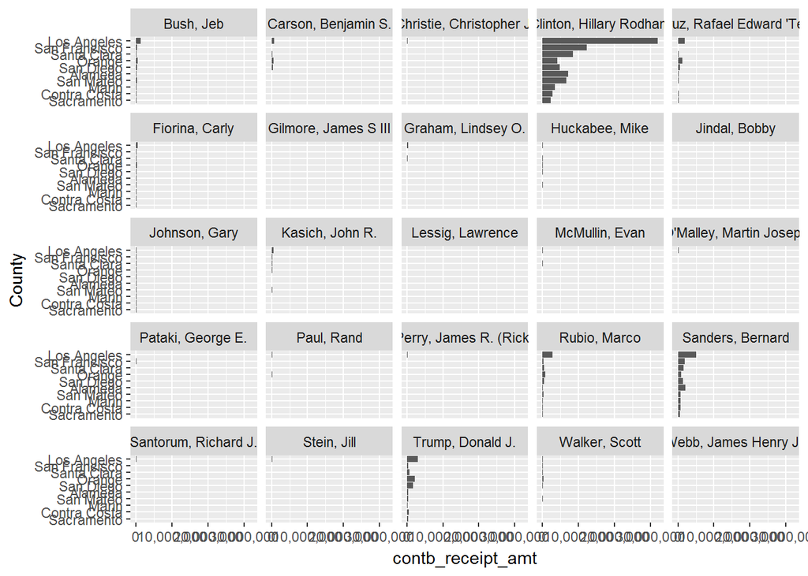

Next, I’d like to see the contribution amount by each candidate, in top 5 counties.

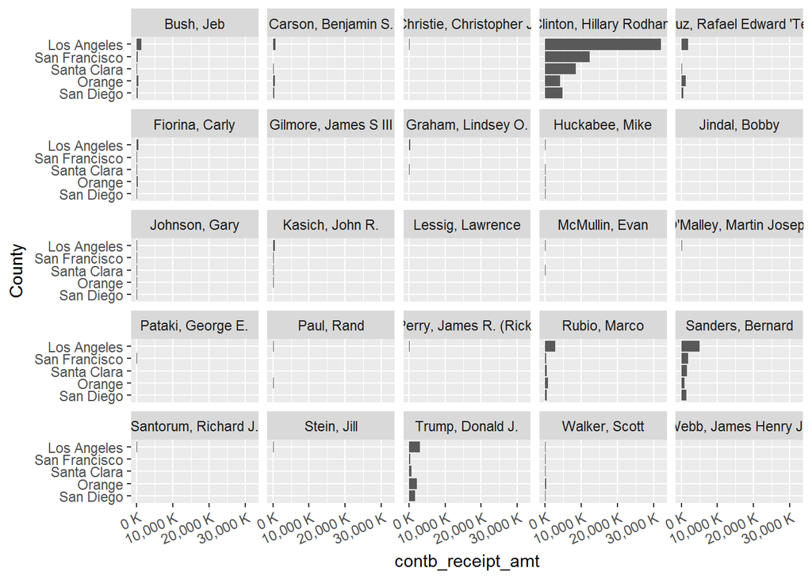

The above plot shows Hillary receive significant higher contribution in top 5 counties than all other candidates.

Next, I’d like to visualize the total contribution amount by date, and further to split by Political Party.

```
## # A tibble: 61 x 4
## # Groups:   date [?]
##             date            party sum_amt     n
##    <S3: yearmon>           <fctr>   <dbl> <int>
##  1      Sep 2015 Democratic Party 3293600 10467
##  2      Sep 2015      Green Party     130     4
##  3      Sep 2015 Republican Party 3155111  7800
##  4      Oct 2015 Democratic Party 3619086 18562
##  5      Oct 2015      Green Party     570     6
##  6      Oct 2015 Republican Party 1568261  7937
##  7      Nov 2015 Democratic Party 1865664 14417
##  8      Nov 2015      Green Party    1720    15
##  9      Nov 2015 Republican Party 1827901  8789
## 10      Dec 2015 Democratic Party 3667403 24541
## # ... with 51 more rows
```

The first plot is using bar plot to visualize it, it shows increasing trend of number of contribution made toward election day, and Democratic Party is always the big winner.

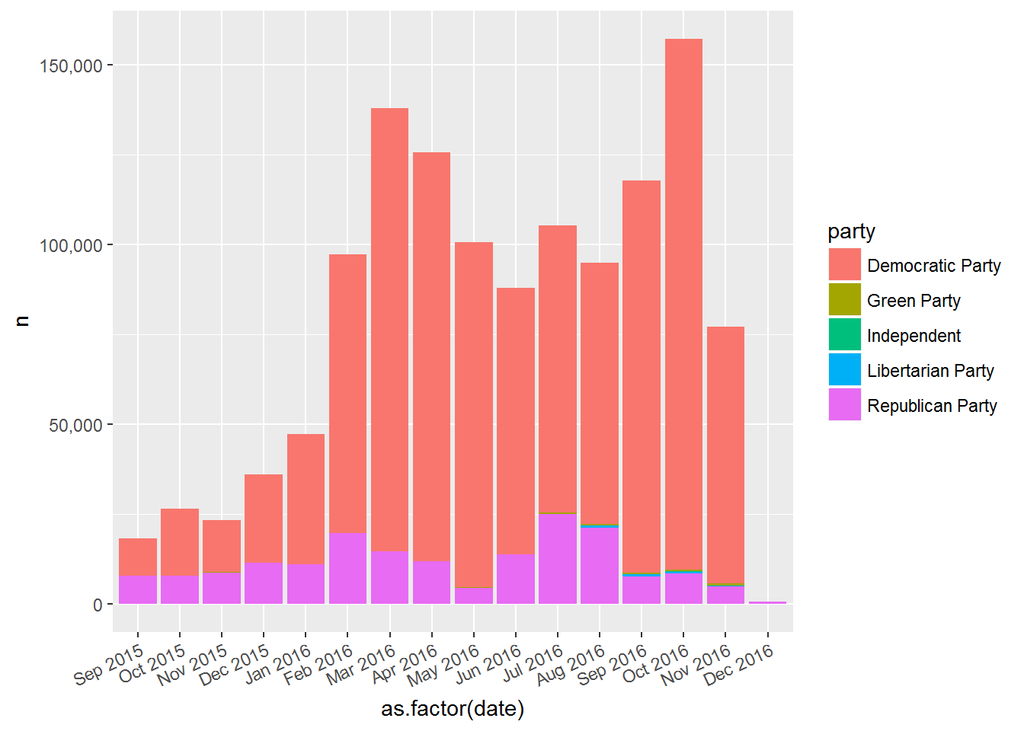

Next, I change the plot to visualize contribution amount rather than number of contribution on y-axis, and it shows more steady increasing trend, but comparing to above plot, the % of Democratic party contribution amount is not as far off as the number of contribution made, which singal that the average contribution amount to Democratic Party is lower than Republican Party.

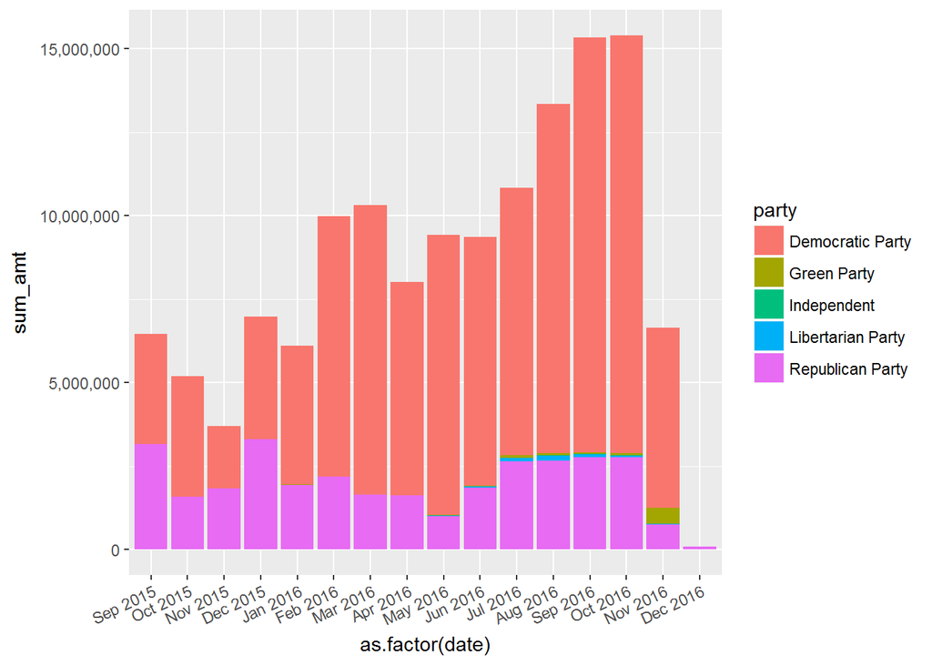

Next, I would like to convert above stacked plot to a line plot because it is easier to compare between different parties.

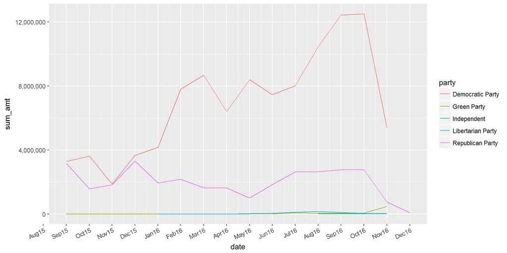

The above plot shows the up and down of each month. Democratic party received contriubtion start ramping up starting Jan-16 which I believe should be the start time of major presidential campaign. And Republican Party is comparatively more consistnet around $2M each month.

Next, the same plot but substitude the y-axis to count of contribution made each month. It follows the same increasing trend as the above plot. The thing caught my attention is a drop in Jun-16 timeframe for Democratic Party. I don’t see an obvious drop in the plot above shows contribution amount, soI think the average contribution amount should be higher at during that time frame to keep up the total contribution amount at the similar level as prior months.

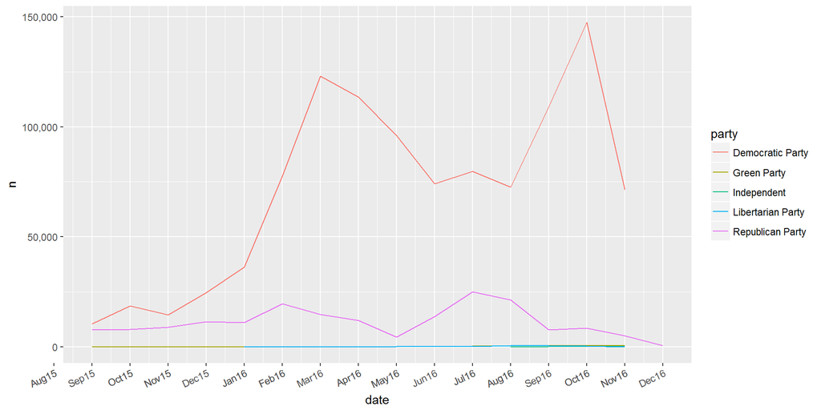

Next, I will look at the count of contribution to each of he top 10 candidate by date, hoping to see the trend of each candidate’s receiving contribution.

```
## # A tibble: 318 x 4
## # Groups:   date [31]
##             date                 cand_nm  sum_amt      n
##    <S3: yearmon>                  <fctr>    <dbl>  <int>
##  1      Oct 2016 Clinton, Hillary Rodham 12510418 147506
##  2      Sep 2016 Clinton, Hillary Rodham 12436324 109082
##  3      Aug 2016 Clinton, Hillary Rodham 10471854  72512
##  4      Jul 2016 Clinton, Hillary Rodham  7821993  73460
##  5      Jun 2016 Clinton, Hillary Rodham  6453907  45908
##  6      May 2016 Clinton, Hillary Rodham  6030364  37606
##  7      Nov 2016 Clinton, Hillary Rodham  5381774  71361
##  8      Mar 2016        Sanders, Bernard  4359933  93914
##  9      Mar 2016 Clinton, Hillary Rodham  4313076  29231
## 10      Feb 2016 Clinton, Hillary Rodham  4308264  22004
## # ... with 308 more rows
```

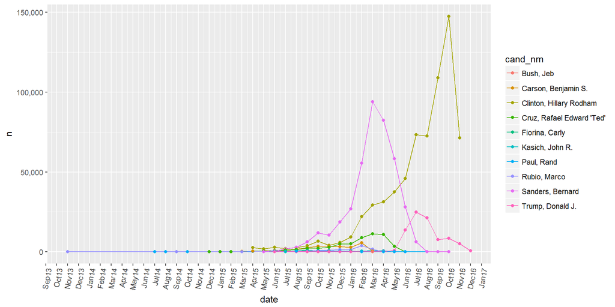

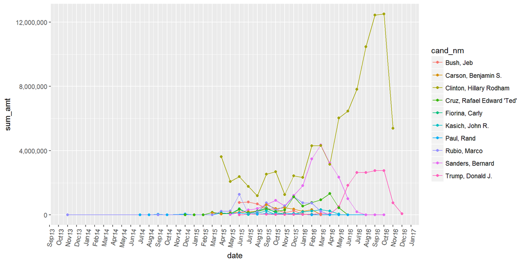

# Multivariate Analysis

### Were there any interesting or surprising interactions between features?

It is interesting to see that Orange county is the only couny in top 10 counties that contribution to Female are lower than Male. And another plot shows the reason is due to the contribution to Donald Trump is pretty strong in Orange. All other top 10 counties are giving Hillary Clinton the contribution higher than all other male candidate combined.

### OPTIONAL: Did you create any models with your dataset? Discuss the strengths and limitations of your model.

N/A

# Final Plots and Summary

### Plot One

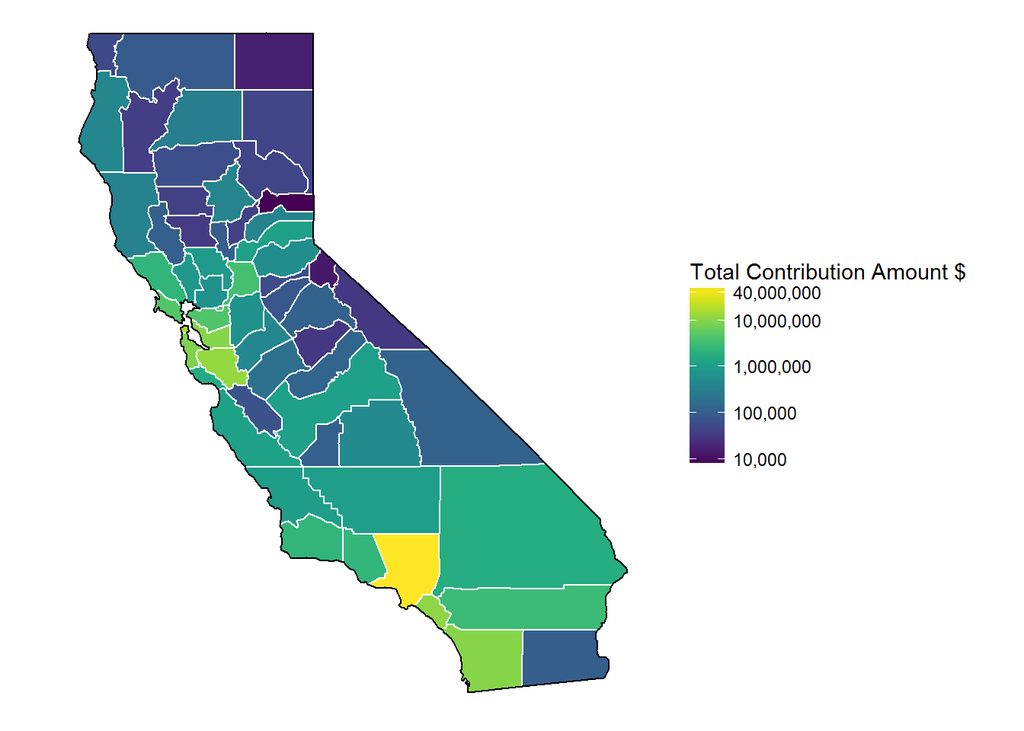

### Plot Two

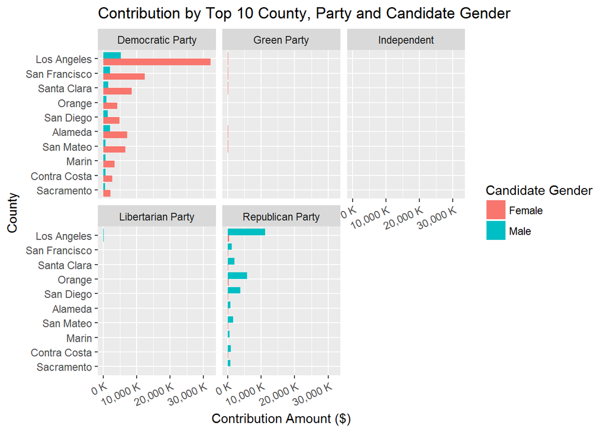

### Description Two

The second plot shows the contributino amount by top 10 counties, by political paries and by candidate gender. This shows Democratic Party receive significant higher contribution amount compare to other party, shows that California is Democratic state. Within Democratic Party, contribution to Female candidate greatly exceed Male candidates, and the reason must be Hillary Clinton is the wining candidate in California. Republican Party is the second to Democratic Party, but lower by large margin than Democratic Party. Within Republican Party, majority of contribution are made to male candidate. If compare Republican Party to Democratic Party, the Orange county is the only one that Republican receive more contribution amount than Democratic. This shows Orange county to have stronger supporter to Republican Party, specifically to Donald Trump.

### Plot Three

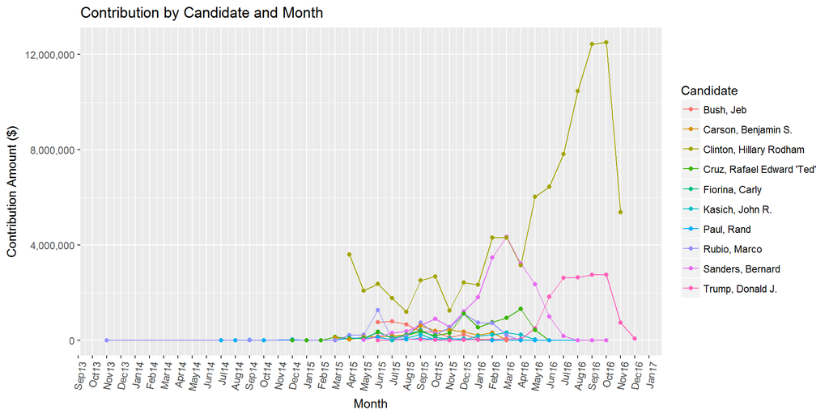

### Description Three

The third plot shows the contribution amount by candidate and by month. This shows Hillary Clinton is the highest contribution receiving candidate at all time except prior to Apr-15 which no contribution made to Hillary yet, and Mar-16 which Bernard is higher by small margin. Hillary’s contribution skyrocket starting Apr-16, and may be interesting to look into what is the trigger event in later study. Bernard Sanders is the second highest receiving contribution in California. Starting Mar-16 Bernard’s contribution going downward trend, and drop to almost zero on Aug-16, that coincile with Bernard drop out election in Jul-16. Donald Trump’s contribution start ramping up around Apr-16, and it peak at Jul-16 to Oct-16, it coincile with Donald Trump’s offical nomination on Jul-16.

# Reflection

My analysis’s major interest feature is the contribution amount, and I explore this with different measures including by candidate, by politcal party, by candidate gender, by date, by county, etc. At the same time, I substitude contribution amount with the count of contribution to explore the difference between count and amount. From above analysis, I get to know more understanding of California’s contribution between different party, different candidate, different timing. The increasing trend of contribution amount is expected, and Hillary is almost always the top 1 receiving candidates in top 10 counties, that also makes Female won the majority of contribution than Male in all top 10 counties. So it is interesting to see Orange county is the only county that Male candidate get more overall contribution amount than Female candidate, and upon digging further it shows the Orange county’s contribution to Donald Trump is pretty high.

The analysis also proves to me that California is Democratic state because the contribution amount to Democratic party is significant higher than to Democratic party. The geographical map with color scale also shows Los Angeles and San Francisco is the top 2 county with highest contribution amount, and for counties that are farther away from these 2 metropolitan, it tends to get lower contribution amount, which makes sense because metropolitan should have most densed population with richer communities.

My biggest struggle when performing above analysis is there are many ggplot syntax that I was not familiar with, and have done quite a lot of online search in order to accomplish something simple. For example, to plot the contribution trend by date, the method scale_x_date works well with geom_bar or histogram, but when I try to create group_by dataframe by Month-Year, I notice the pure date doesn’t work well in this situation. Finally, I find zoo library’s yearmon() function that help me to create group_by dataframe, and further apply the scale_x_yearmon() to the ggplot to complete it. Things in R gets simple once I know how, but it takes time to find these key function. I am glad to work on this project that familiarize myself with many different way of visualization using ggplot, and I become comfortable with making plot for exploratory analysis with R.

To further elaborate my analysis, I would like to introduce another dataset about campaign’s timing, type and location that took place, and I may further evaluate the success and effect of these presidential campaign. Also, I may want to introduce the population number by county, so that I can assess the actual % contributor out of total population to measure involvement by county, and also get per capita contribution amount.